# Analysis - Only Amendments

> Quid pro quo? An explanation for why partisan alignment pays off

# Data

The unit of analysis in our dataset is the pair municipality $i$ ministry $j$ observerd in year $t$. In total, this structure comprises `740112` observations, with `5565` unique municipalities and `17` unique ministries.

## Proposals

In our sample, municipalities requested on average `39525.02` Brazilian reais (adjusted for inflation) between 2009 and 2016, or `2.84` reais per capita. There is a total of `61522` proposals that were submited by municipalities to the Federal Government requesting transfers. Finally, of all municipality-ministry-year units, `696681` did not submit any proposals, `94.1%` of all units.

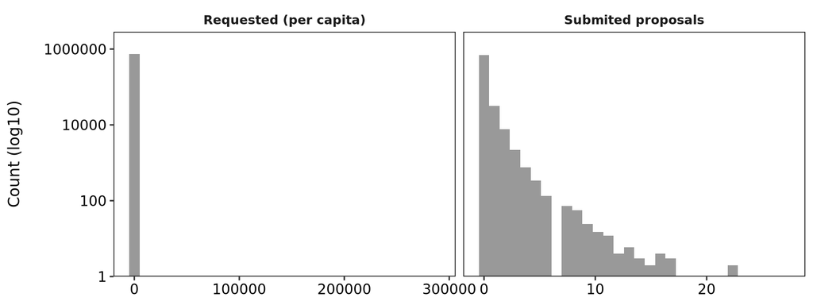

## Ministries

The plot below the distribution of submited proposals by ministries they targeted.

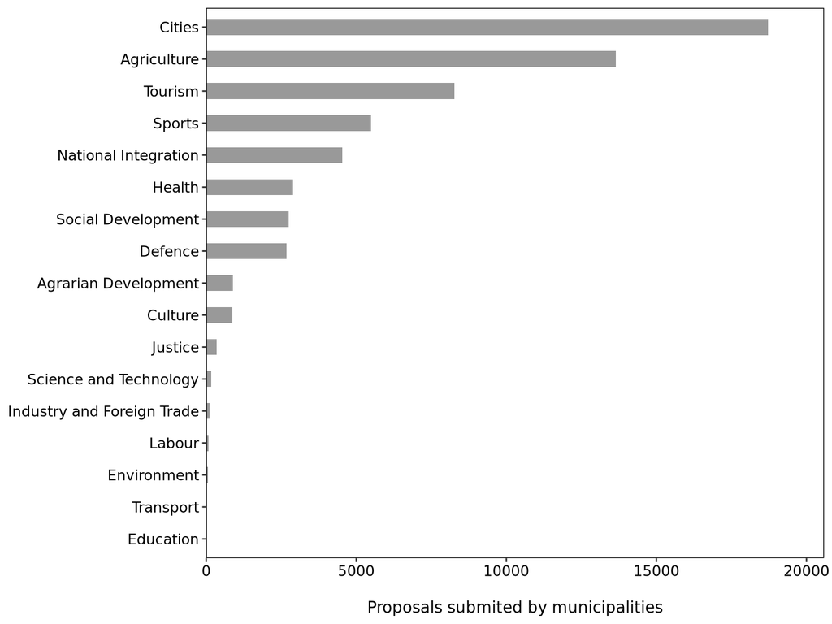

# Partisan Aligment

## Difference in means

### Considering non-responders as zero

Below we estimate differences in distributive outcomes between aligned and non-aligned municipality-ministry pairs. In particular, for values we do not observe in variables such as `Proportion of rejected proposals` (i.e., we only observe rejection status for municipalities that submited proposals) we input the value of zero. In this way, we deal with attrition by assuming non-submission as an inferior type of submission.

|  | Non-aligned (N=655444) Mean | Non-aligned (N=655444) Std. Dev. | Aligned (N=81336) Mean | Aligned (N=81336) Std. Dev. | Diff. in Means | Std. Error |
| --- | --- | --- | --- | --- | --- | --- |
| Submited proposals | 0.08 | 0.39 | 0.14 | 0.52 | 0.06 | 0.00 |
| empenhado_per capita | 1.15 | 11.43 | 2.34 | 15.18 | 1.19 | 0.06 |
| N convenios | 0.04 | 0.28 | 0.09 | 0.38 | 0.04 | 0.00 |
| Prop. rejected proposals | 0.00 | 0.07 | 0.01 | 0.08 | 0.00 | 0.00 |
| Avg. attachments | 0.39 | 2.28 | 0.74 | 3.09 | 0.35 | 0.01 |
| Avg. object word count | 0.69 | 4.65 | 1.13 | 6.07 | 0.44 | 0.02 |
| Avg. justification word count | 16.88 | 84.72 | 34.02 | 124.54 | 17.14 | 0.45 |
| Prop. ata posse | 0.16 | 1.64 | 0.26 | 1.97 | 0.10 | 0.01 |
| Prop. plano de trabalho | 0.14 | 1.44 | 0.28 | 1.96 | 0.15 | 0.01 |
| Prop. cotações | 0.12 | 1.40 | 0.23 | 1.86 | 0.11 | 0.01 |
| Prop. cronograma | 0.03 | 0.67 | 0.05 | 0.87 | 0.02 | 0.00 |
| Avg. payments to providers | 0.16 | 1.48 | 0.28 | 1.60 | 0.12 | 0.01 |
| Avg. number of providers | 0.05 | 0.39 | 0.09 | 0.49 | 0.04 | 0.00 |
| Avg. providers’ time in operation | 0.42 | 2.96 | 0.85 | 4.27 | 0.43 | 0.02 |
| Avg. diárias payments | 0.00 | 0.00 | 0.00 | 0.00 | 0.00 | 0.00 |
| Provider donnor (dummy) | 0.00 | 0.01 | 0.00 | 0.01 | 0.00 | 0.00 |

### Subsample

In this part, we reestimate the difference in means using a sub-sample of our data that contains a smaller proportion of non-observed outcomes. To that end, we subseted ou sample to include only the following ministries: “National Integration”, “Health”, “Cities”, “Agriculture”, “Tourism”, “Sports”. In addition, we filtered out municipalities with fewer than 30k inhabitants. After these procedures, our resulting sample have `50028` observations, with `39896` that did not submit any proposals, `79.7%`.

|  | Non-aligned (N=43051) Mean | Non-aligned (N=43051) Std. Dev. | Aligned (N=6839) Mean | Aligned (N=6839) Std. Dev. | Diff. in Means | Std. Error |
| --- | --- | --- | --- | --- | --- | --- |
| Submited proposals | 0.33 | 0.83 | 0.35 | 0.83 | 0.03 | 0.01 |
| empenhado_per capita | 1.16 | 5.71 | 1.59 | 8.33 | 0.43 | 0.10 |
| N convenios | 0.19 | 0.58 | 0.23 | 0.62 | 0.04 | 0.01 |
| Prop. rejected proposals | 0.01 | 0.10 | 0.01 | 0.09 | -0.00 | 0.00 |
| Avg. attachments | 1.31 | 3.96 | 1.67 | 4.45 | 0.36 | 0.06 |
| Avg. object word count | 2.66 | 8.54 | 2.84 | 11.63 | 0.18 | 0.15 |
| Avg. justification word count | 62.10 | 153.57 | 80.90 | 181.39 | 18.80 | 2.31 |
| Prop. ata posse | 0.63 | 3.28 | 0.71 | 3.26 | 0.07 | 0.04 |
| Prop. plano de trabalho | 0.40 | 2.48 | 0.55 | 2.76 | 0.15 | 0.04 |
| Prop. cotações | 0.31 | 2.28 | 0.39 | 2.40 | 0.08 | 0.03 |
| Prop. cronograma | 0.11 | 1.33 | 0.11 | 1.25 | 0.00 | 0.02 |
| Avg. payments to providers | 0.68 | 2.72 | 0.75 | 2.71 | 0.07 | 0.04 |
| Avg. number of providers | 0.16 | 0.58 | 0.20 | 0.68 | 0.04 | 0.01 |
| Avg. providers’ time in operation | 1.66 | 5.80 | 2.04 | 6.53 | 0.38 | 0.08 |
| Avg. diárias payments | 0.00 | 0.00 | 0.00 | 0.00 | 0.00 | 0.00 |
| Provider donnor (dummy) | 0.00 | 0.03 | 0.00 | 0.04 | 0.00 | 0.00 |

## Difference-in-Differences

### Main variables

|  | empenhado_per capita (DiD) | empenhado_per capita (DDD) | Submited proposals (DiD) | Submited proposals (DDD) |
| --- | --- | --- | --- | --- |
| Partisan aligment | 0.24* | 0.31* | 0.01** | 0.01* |
|  | (0.11) | (0.12) | (0.00) | (0.00) |
| Num.Obs. | 736780 | 736780 | 736780 | 736780 |
| Std.Errors | by: cod_ibge | by: cod_ibge | by: cod_ibge | by: cod_ibge |

### Quality of proposals

|  | Partisan aligment |
| --- | --- |
| Prop. rejected proposals (DiD) | 0.00 [0.00, 0.00] |
| Prop. rejected proposals (DDD) | 0.00 [0.00, 0.00] |
| Avg. attachments (DiD) | 0.04 [0.00, 0.08]* |
| Avg. attachments (DDD) | 0.04 [0.00, 0.08]* |
| Avg. object word count (DiD) | 0.09 [0.02, 0.17]* |
| Avg. object word count (DDD) | 0.09 [0.01, 0.17]* |
| Avg. just. word count (DiD) | 1.15 [−0.16, 2.46]+ |
| Avg. just. word count (DDD) | 1.01 [−0.52, 2.54] |
| Prop. ata posse (DiD) | 0.00 [−0.02, 0.03] |
| Prop. ata posse (DDD) | 0.01 [−0.02, 0.03] |
| Prop. plano de trabalho (DiD) | 0.03 [0.01, 0.06]** |
| Prop. plano de trabalho (DDD) | 0.03 [0.01, 0.06]** |
| Prop. cotações (DiD) | 0.01 [−0.02, 0.03] |
| Prop. cotações (DDD) | 0.00 [−0.02, 0.02] |
| Prop. cronograma (DiD) | −0.01 [−0.02, 0.00]+ |
| Prop. cronograma (DDD) | −0.01 [−0.02, 0.00] |

### Quality of providers

|  | Partisan aligment |
| --- | --- |
| Avg. payments to providers (DiD) | 0.02 [−0.01, 0.04] |
| Avg. payments to providers (DDD) | 0.02 [0.00, 0.05]+ |
| Avg. number of providers (DiD) | 0.01 [0.00, 0.01]** |
| Avg. number of providers (DDD) | 0.01 [0.00, 0.02]** |
| Avg. providers’ time in operation (DiD) | 0.04 [0.00, 0.09]+ |
| Avg. providers’ time in operation (DDD) | 0.05 [0.00, 0.11]+ |
| At least 1 small company (dummy) (DiD) | 0.00 [0.00, 0.01]** |
| At least 1 small company (dummy) (DDD) | 0.01 [0.00, 0.01]*** |
| Provider donnor (dummy) (DiD) | 0.00 [0.00, 0.00] |
| Provider donnor (dummy) (DDD) | 0.00 [0.00, 0.00] |